# **Milestone 2**

### **Insights**

**Refined insights**:

- What are the most meaningful insights from the data relevant to the problem?

**Comparison of various techniques and their relative performance**:

- How do different techniques perform? Which one is performing relatively better? Is there scope to improve the performance further?

**Proposal for the final solution design**:

- What model do you propose to be adopted? Why is this the best solution to adopt?

Revise hyperparamters of Random Forest so that it increases performance but also reduces overfitting

```python
# Choose the type of Regressor
rf_tuned_2 = RandomForestRegressor(random_state = 1)

# Define the parameters for Grid to choose from
parameters = {"n_estimators": [110, 120],

    "max_depth": [2, 8, 12],

    "max_features": [0.8, 1]
             }

# Check documentation for all the parametrs that the model takes and play with those

# Type of scoring used to compare parameter combinations
scorer = make_scorer(r2_score)


# Run the grid search
grid_obj = GridSearchCV(rf_tuned_2, parameters, scoring = scorer, cv = 5)

grid_obj = grid_obj.fit(X_train, y_train)

# Set the model to the best combination of parameters
rf_tuned_2_regressor = grid_obj.best_estimator_

rf_tuned_2_regressor.fit(X_train, y_train)
# Fit the best algorithm to the data
```

```
RandomForestRegressor(max_depth=12, max_features=0.8, n_estimators=120,
                      random_state=1)
```

```python
grid_obj = GridSearchCV(rf_tuned_2, parameters, scoring = scorer, cv = 5)
```

```python
# Get score of the model
pred_train = rf_tuned_2_regressor.predict(X_train)
pred_test = rf_tuned_2_regressor.predict(X_test)
train_r2 = metrics.r2_score(y_train, pred_train)
test_r2 = metrics.r2_score(y_test, pred_test)
train_rmse = metrics.mean_squared_error(y_train, pred_train, squared = False)
test_rmse = metrics.mean_squared_error(y_test, pred_test, squared = False)

score_list = []
score_list.extend((train_r2, test_r2, train_rmse, test_rmse))

# If the flag is set to True then only the following print statements will be dispayed, the default value is True

print("R-square on training set : ", metrics.r2_score(y_train, pred_train))

print("R-square on test set : ", metrics.r2_score(y_test, pred_test))

print("RMSE on training set : ", np.sqrt(metrics.mean_squared_error(y_train, pred_train)))

print("RMSE on test set : ", np.sqrt(metrics.mean_squared_error(y_test, pred_test)))
```

```
R-square on training set :  0.9819008830966992
R-square on test set :  0.9454933319698942
RMSE on training set :  0.1171887048636904
RMSE on test set :  0.20517814759637243
```

```python
scores = cross_val_score(rf_tuned_2_regressor, X, y, cv=5, scoring='r2')
print('R-squared scores:', scores)
Cross_scores_2 = np.mean(scores)
Cross_scores_2
```

```
R-squared scores: [0.9501888  0.92523376 0.93399875 0.94085358 0.93470323]
```

```
0.9369956242098126
```

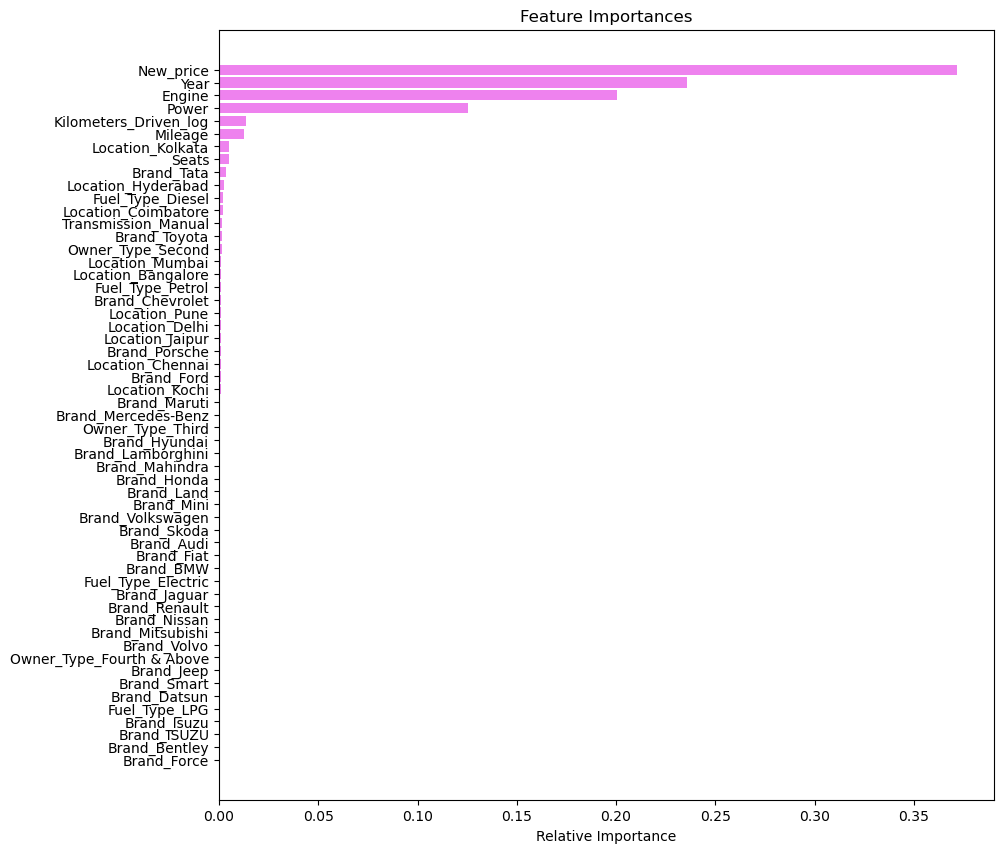

```python
# Print important features of tuned random forest similar to decision trees
# Plotting the feature importance
importances = rf_tuned_2_regressor.feature_importances_

indices = np.argsort(importances)

plt.figure(figsize = (10, 10))

plt.title('Feature Importances')

plt.barh(range(len(indices)), importances[indices], color = 'violet', align = 'center')

plt.yticks(range(len(indices)), [features[i] for i in indices])

plt.xlabel('Relative Importance')

plt.show()
```

Start of a new approach

```python
# Choose the type of Regressor
rf_tuned_3 = RandomForestRegressor(random_state = 1)

# Define the parameters for Grid to choose from
parameters = {'n_estimators': [50, 100, 150, 200],

'max_depth': [None, 1, 2, 3, 4, 5],

'min_samples_leaf': [1, 2, 3],

'min_weight_fraction_leaf': [0, 0.5],

'warm_start': [True, False],

'max_leaf_nodes': [2, 5, 7] + [None]

             }

# Check documentation for all the parametrs that the model takes and play with those

# Type of scoring used to compare parameter combinations
scorer = make_scorer(r2_score)


# Run the grid search
grid_obj = GridSearchCV(rf_tuned_3, parameters, scoring = scorer, cv = 5)

grid_obj = grid_obj.fit(X_train, y_train)

# Set the model to the best combination of parameters
rf_tuned_3_regressor = grid_obj.best_estimator_

rf_tuned_3_regressor.fit(X_train, y_train)
# Fit the best algorithm to the data
```

```
RandomForestRegressor(min_weight_fraction_leaf=0, n_estimators=200,
                      random_state=1, warm_start=True)
```

```python
grid_obj = GridSearchCV(rf_tuned_3, parameters, scoring = scorer, cv = 5)
```

```python
# Get score of the model
pred_train = rf_tuned_3_regressor.predict(X_train)
pred_test = rf_tuned_3_regressor.predict(X_test)
train_r2 = metrics.r2_score(y_train, pred_train)
test_r2 = metrics.r2_score(y_test, pred_test)
train_rmse = metrics.mean_squared_error(y_train, pred_train, squared = False)
test_rmse = metrics.mean_squared_error(y_test, pred_test, squared = False)

score_list = []
score_list.extend((train_r2, test_r2, train_rmse, test_rmse))

# If the flag is set to True then only the following print statements will be dispayed, the default value is True

print("R-square on training set : ", metrics.r2_score(y_train, pred_train))

print("R-square on test set : ", metrics.r2_score(y_test, pred_test))

print("RMSE on training set : ", np.sqrt(metrics.mean_squared_error(y_train, pred_train)))

print("RMSE on test set : ", np.sqrt(metrics.mean_squared_error(y_test, pred_test)))
```

```
R-square on training set :  0.9917870309524318
R-square on test set :  0.9471057371605374
RMSE on training set :  0.07894182367682667
RMSE on test set :  0.20212059672938443
```

```python
scores = cross_val_score(rf_tuned_3_regressor, X, y, cv=5, scoring='r2')
print('R-squared scores:', scores)
Cross_scores_3= np.mean(scores)
Cross_scores_3
```

```
R-squared scores: [0.95284951 0.92612163 0.93605678 0.94383571 0.93885294]
```

```
0.9395433145851552
```

```python
# Choose the type of Regressor
rf_tuned_4 = RandomForestRegressor(random_state = 1)

# Define the parameters for Grid to choose from
parameters = {'n_estimators': [50, 100, 150, 200],

'max_depth': [None, 1, 2, 3, 4, 5],

'min_samples_leaf': [1, 2, 3],

'min_weight_fraction_leaf': [0, 0.5],

'warm_start': [True, False],

'max_leaf_nodes': [2, 5, 7] + [None],

'max_features': [0.25, 0.5]
             }

# Check documentation for all the parametrs that the model takes and play with those

# Type of scoring used to compare parameter combinations
scorer = make_scorer(r2_score)


# Run the grid search
grid_obj = GridSearchCV(rf_tuned_4, parameters, scoring = scorer, cv = 5)

grid_obj = grid_obj.fit(X_train, y_train)

# Set the model to the best combination of parameters
rf_tuned_4_regressor = grid_obj.best_estimator_

rf_tuned_4_regressor.fit(X_train, y_train)
# Fit the best algorithm to the data
```

```
RandomForestRegressor(max_features=0.5, min_weight_fraction_leaf=0,
                      n_estimators=200, random_state=1, warm_start=True)
```

```python
grid_obj = GridSearchCV(rf_tuned_4, parameters, scoring = scorer, cv = 5)
```

```python
# Get score of the model
pred_train = rf_tuned_4_regressor.predict(X_train)
pred_test = rf_tuned_4_regressor.predict(X_test)
train_r2 = metrics.r2_score(y_train, pred_train)
test_r2 = metrics.r2_score(y_test, pred_test)
train_rmse = metrics.mean_squared_error(y_train, pred_train, squared = False)
test_rmse = metrics.mean_squared_error(y_test, pred_test, squared = False)

score_list = []
score_list.extend((train_r2, test_r2, train_rmse, test_rmse))

# If the flag is set to True then only the following print statements will be dispayed, the default value is True

print("R-square on training set : ", metrics.r2_score(y_train, pred_train))

print("R-square on test set : ", metrics.r2_score(y_test, pred_test))

print("RMSE on training set : ", np.sqrt(metrics.mean_squared_error(y_train, pred_train)))

print("RMSE on test set : ", np.sqrt(metrics.mean_squared_error(y_test, pred_test)))
```

```
R-square on training set :  0.9922266924696486
R-square on test set :  0.9525633493770396
RMSE on training set :  0.07679978193056776
RMSE on test set :  0.1914094149369222
```